# Linear Model Selection and Regularization - Full

# 8

In this exercise, we will generate simulated data, and will then use this data to perform best subset selection.

## a

Use the rnorm() function to generate a predictor X of length n = 100, as well as a noise vector e of length n = 100.

```r
set.seed(1)
x = rnorm(n = 100)
e = rnorm(n = 100, mean = 0, sd = 5)
```

## b

Generate a response vector Y of length n = 100 according to the model $Y = \beta_0 + \beta_1X + \beta_2X^2 + \beta_3X^3 + \epsilon$, where B0 through B3 are constants of your choice.

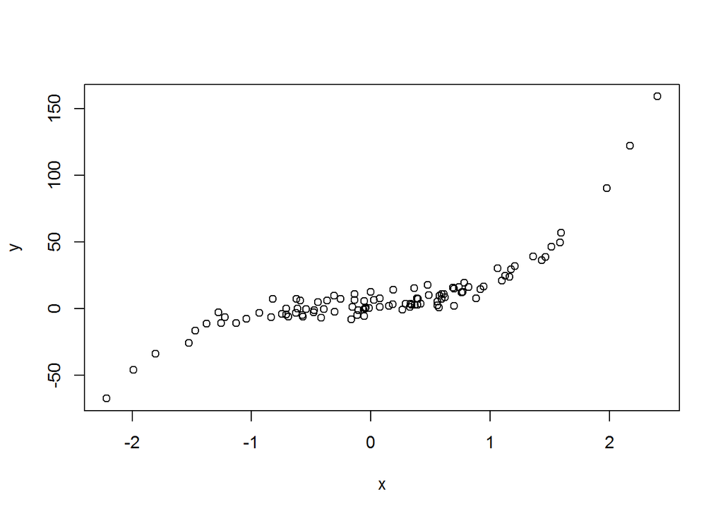

```r
y = 2 + 4*x + 6*(x^2) + 8*(x^3) + e
plot(x, y)
```

## c

Use the regsubsets() function to perform best subset selection in order to choose the best model containing the predictors X, X2,…,X10. What is the best model obtained according to Cp, BIC, and adjusted R-squared? Show some plots to provide evidence for your answer, and report the coefficients of the best model obtained.

```r
library(leaps)
```

```r
data = data.frame(y = y, x = x)
head(data)
```

|  | y | x |
| --- | --- | --- |
| 1 | -3.2197686 | -0.6264538 |
| 2 | 3.1970487 | 0.1836433 |
| 3 | -6.3754614 | -0.8356286 |
| 4 | 56.9196989 | 1.5952808 |
| 5 | 0.9827715 | 0.3295078 |
| 6 | 7.1750661 | -0.8204684 |

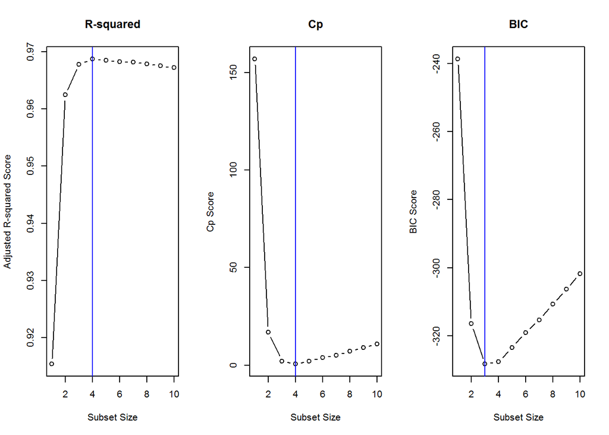

```r
fit = regsubsets(y ~ poly(x, degree = 10, raw = T), data = data, nvmax = 10)
sfit = summary(fit)

par(mfrow = c(1,3))
{
  plot(sfit$adjr2, type = 'b', ylab = "Adjusted R-squared Score", xlab = "Subset Size", main = "R-squared")
  abline(v = which.max(sfit$adjr2), col = "blue")
  plot(sfit$cp, type = 'b', ylab = "Cp Score", xlab = "Subset Size", main = "Cp")
  abline(v = which.min(sfit$cp), col = "blue")
  plot(sfit$bic, type = 'b', ylab = "BIC Score", xlab = "Subset Size", main = "BIC")
  abline(v = which.min(sfit$bic), col = "blue")
}
```

```r
# Difference in BIC Scores when P = 4 and P = 3:
print(sfit$bic[4] - sfit$bic[3])
```

```
## [1] 0.7309448
```

The adjusted R-squared and Cp statistics have the best scores when the number of predictors was four, and the BIC had the best score when the number of predictors was three.

Does this matter? An article on the subject: https://www.methodology.psu.edu/resources/aic-vs-bic/. Also note that the Cp (i.e. Mallows Cp) is a a variant of AIC developed by Colin Mallows, so we can assume the comments in the PSU article apply equally to the Cp statistic.

From the article:

> But despite various subtle theoretical differences, their [i.e. AIC/Cp and BIC] only difference in practice is the size of the penalty; BIC penalizes model complexity more heavily. The only way they should disagree is when AIC chooses a larger model than BIC.

And this is exactly what we see above where the Cp model optimizes at four parameters and the BIC model optimizes on three. For all intents and purposes then we will say the best model using best subset selection is P = 3 (i.e. we’ll favor the simpler model over the more complex one).

The coefficients for P = 3 are:

```r
coefficients(fit, id = 3)
```

```
##                    (Intercept) poly(x, degree = 10, raw = T)1
##                       2.307536                       3.876401
## poly(x, degree = 10, raw = T)2 poly(x, degree = 10, raw = T)3
##                       5.381045                       8.088193
```

These are very close to the true beta values of (2,4,6,8). The coefficients for P = 4 for comparison:

```r
coefficients(fit, id = 4)
```

```
##                    (Intercept) poly(x, degree = 10, raw = T)1
##                      2.3600387                      5.9372798
## poly(x, degree = 10, raw = T)2 poly(x, degree = 10, raw = T)3
##                      5.2287821                      5.7898713
## poly(x, degree = 10, raw = T)5
##                      0.4036146
```

## d

### Forward stepwise selection

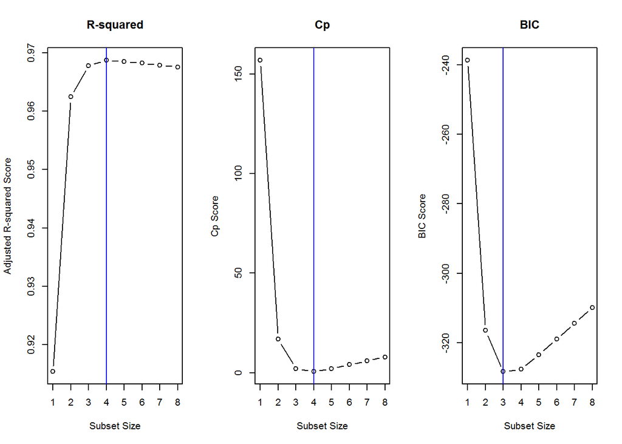

```r
# Forward stepwise selection
fit = regsubsets(y ~ poly(x, degree = 10, raw = T), data = data, method = 'forward')
sfit = summary(fit)

par(mfrow = c(1,3))
{
  plot(sfit$adjr2, type = 'b', ylab = "Adjusted R-squared Score", xlab = "Subset Size", main = "R-squared")
  abline(v = which.max(sfit$adjr2), col = "blue")
  plot(sfit$cp, type = 'b', ylab = "Cp Score", xlab = "Subset Size", main = "Cp")
  abline(v = which.min(sfit$cp), col = "blue")
  plot(sfit$bic, type = 'b', ylab = "BIC Score", xlab = "Subset Size", main = "BIC")
  abline(v = which.min(sfit$bic), col = "blue")
}
```

### Backward stepwise selection

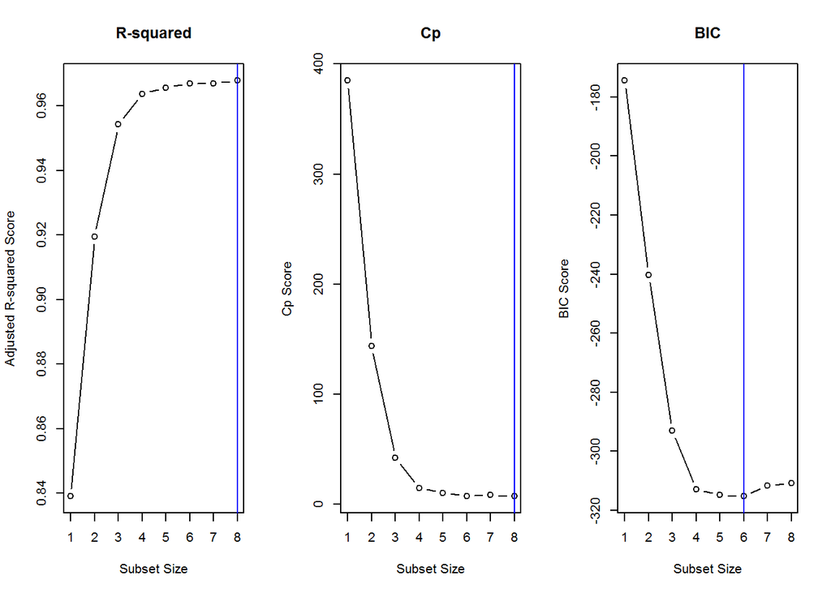

```r
# Forward stepwise selection
fit = regsubsets(y ~ poly(x, degree = 10, raw = T), data = data, method = 'backward')
sfit = summary(fit)

par(mfrow = c(1,3))
{
  plot(sfit$adjr2, type = 'b', ylab = "Adjusted R-squared Score", xlab = "Subset Size", main = "R-squared")
  abline(v = which.max(sfit$adjr2), col = "blue")
  plot(sfit$cp, type = 'b', ylab = "Cp Score", xlab = "Subset Size", main = "Cp")
  abline(v = which.min(sfit$cp), col = "blue")
  plot(sfit$bic, type = 'b', ylab = "BIC Score", xlab = "Subset Size", main = "BIC")
  abline(v = which.min(sfit$bic), col = "blue")
}
```

Again the Cp and BIC differ in model size, but as we discussed earlier it is to be expected and makes sense. We’ll settle on the best subset selection where P = 6 (again favoring the simpler model) and examine the coefficients:

```r
coefficients(fit, id = 6)
```

```
##                    (Intercept) poly(x, degree = 10, raw = T)1
##                      3.2434781                      8.8548673
## poly(x, degree = 10, raw = T)4 poly(x, degree = 10, raw = T)5
##                      5.0565601                      3.0760097
## poly(x, degree = 10, raw = T)6 poly(x, degree = 10, raw = T)7
##                     -1.6739044                     -0.3343928
## poly(x, degree = 10, raw = T)8
##                      0.1774031
```

## e

Now fit a lasso model to the simulated data, again using X, X2<sup>,…,X</sup>10 as predictors. Use cross-validation to select the optimal value of lambda. Create plots of the cross-validation error as a function of lambda. Report the resulting coefficient estimates, and discuss the results obtained.

```r
library(glmnet)
```

The `glmnet` function supports both Ridge Regression and Lasso.

- If `alpha = 1` is the lasso penalty is applied, and if `alpha = 0` the ridge penalty is applied.
- By default `glmnet` computes its own lambda sequence based on nlambda and lambda.min.ratio; supplying a value of lambda overrides this.
- Also by default `glmnet()` standardizes the variables so that they are on the same scale, which is critical for Ridge Regression
- The `glmnet` function also expects an `x` matrix as well as a `y` vector

```r
# Create the X matrix; exclude the intercept
xm = model.matrix(y ~ poly(x, degree = 10, raw = T), data = data)[, -1]
# Collect the Y values
y = y
```

And finally, we’ll want a test and train set:

```r
set.seed(1)

# Half the data is training data
train = sample(1:nrow(xm), nrow(xm)/2)

# The other half is test data
test = (-train)

x.train = xm[train,]
x.test = xm[test,]
y.train = y[train]
y.test = y[test]
```

Fit the Lasso model (note alpha = 1) using cross-validation and plot the error rate:

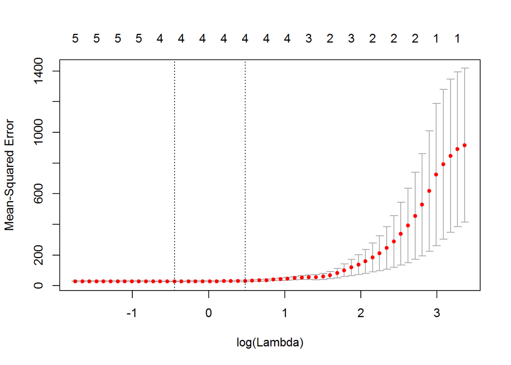

```r
set.seed(1)
cv = cv.glmnet(x.train, y.train, alpha = 1)
plot(cv)
```

We can now made predictions on the test data and compute the error rate:

```r
l = cv$lambda.min
p = predict(cv, s = l, newx = x.test)
err = mean((p - y.test)^2)

{
  print(err)
  print(l)
}
```

```
## [1] 22.68371
## [1] 0.6378912
```

So the error rate is 22.7 with an optimal lambda value of 0.6. If we examine the coefficients we can see that they are sparse (i.e. a number of them have been set to zero) since The Lasso is a variable selection model:

```r
fit = glmnet(xm, y, alpha = 1)
predict(fit, type = "coefficients", s = l)
```

```
## 11 x 1 sparse Matrix of class "dgCMatrix"
##                                          1
## (Intercept)                     3.09367693
## poly(x, degree = 10, raw = T)1  4.39995345
## poly(x, degree = 10, raw = T)2  3.92688346
## poly(x, degree = 10, raw = T)3  7.11997361
## poly(x, degree = 10, raw = T)4  0.21514629
## poly(x, degree = 10, raw = T)5  0.07139138
## poly(x, degree = 10, raw = T)6  .
## poly(x, degree = 10, raw = T)7  0.01440097
## poly(x, degree = 10, raw = T)8  .
## poly(x, degree = 10, raw = T)9  .
## poly(x, degree = 10, raw = T)10 .
```

We can also note that the Lasso model does a fairly good job of picking coefficient values that are close to the true values of Beta. For example we have true vs. model coefficients as intercept 2 => 3.09, first term 4 => 4.4, second term 6 => 3.93, and third term 8 => 7.12.

## f

Now generate a response vector Y according to the model $Y = \beta_0 + \beta_7{X^7} + \epsilon$, and perform best subset selection and the lasso. Discuss the results obtained.

```r
y2 = 2 + 1.5 * (x^7) + e
data2 = data.frame(y2 = y2, x = x)
```

**best subset selection**

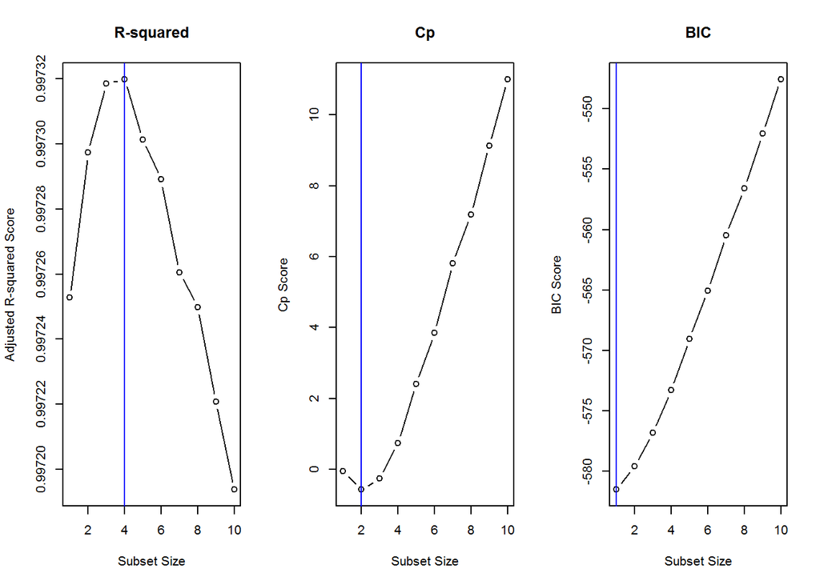

```r
fit = regsubsets(y2 ~ poly(x, degree = 10, raw = T), data = data2, nvmax = 10)
sfit = summary(fit)

par(mfrow = c(1,3))
{
  plot(sfit$adjr2, type = 'b', ylab = "Adjusted R-squared Score", xlab = "Subset Size", main = "R-squared")
  abline(v = which.max(sfit$adjr2), col = "blue")
  plot(sfit$cp, type = 'b', ylab = "Cp Score", xlab = "Subset Size", main = "Cp")
  abline(v = which.min(sfit$cp), col = "blue")
  plot(sfit$bic, type = 'b', ylab = "BIC Score", xlab = "Subset Size", main = "BIC")
  abline(v = which.min(sfit$bic), col = "blue")
}
```

```r
coefficients(fit, id = 1)
```

```
##                    (Intercept) poly(x, degree = 10, raw = T)7
##                       1.794701                       1.503852
```

```r
coefficients(fit, id = 2)
```

```
##                    (Intercept) poly(x, degree = 10, raw = T)2
##                      2.3524518                     -0.7085421
## poly(x, degree = 10, raw = T)7
##                      1.5077759
```

```r
coefficients(fit, id = 4)
```

```
##                    (Intercept) poly(x, degree = 10, raw = T)1
##                      2.3812622                      1.4570080
## poly(x, degree = 10, raw = T)2 poly(x, degree = 10, raw = T)3
##                     -0.8088357                     -1.2632634
## poly(x, degree = 10, raw = T)7
##                      1.5456688
```

**Lasso**

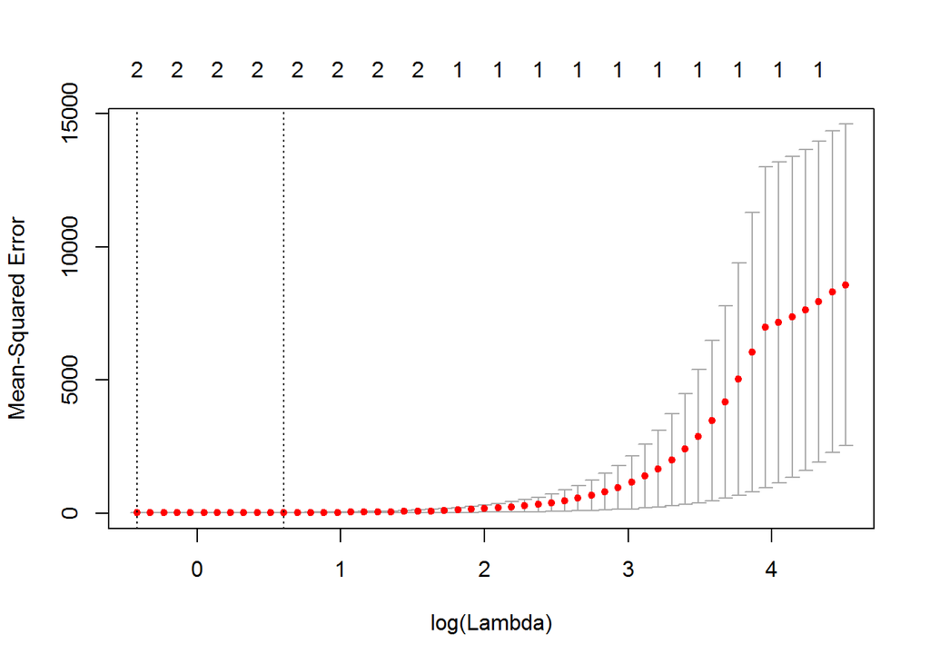

```r
xmat = model.matrix(y2 ~ poly(x, 10 , raw = T))[,-1]
cv = cv.glmnet(xmat, y2, alpha = 1)
l = cv$lambda.min

par(mfrow=c(1,1))

plot(cv)
```

```r
predict(cv, s=l, type="coefficients")
```

```
## 11 x 1 sparse Matrix of class "dgCMatrix"
##                                  1
## (Intercept)            1.832159925
## poly(x, 10, raw = T)1  .
## poly(x, 10, raw = T)2  .
## poly(x, 10, raw = T)3  .
## poly(x, 10, raw = T)4  .
## poly(x, 10, raw = T)5  .
## poly(x, 10, raw = T)6  .
## poly(x, 10, raw = T)7  1.469327430
## poly(x, 10, raw = T)8  .
## poly(x, 10, raw = T)9  0.004555432
## poly(x, 10, raw = T)10 .
```

**discussion**

The best subset selection model picks predictor variable counts of 4, 2, and 1 for the R-squared, Cp, and BIC scores respectively. If we examine the coefficient estimates we see the BIC model’s beta values are almost equal to the true beta values we created the data set with.

The Lasso’s coefficient estimates are also almost equal to the true beta values we created the data set with.

Based on the experiments we’ve conducted above I would tend to favor either best subset selection using BIC or the Lasso to predict the best model and model parameters.

# 9

First, create a dataframe to hold model results:

```r
results =  data.frame(
  Model = character(),
  MSPE = integer(),
  stringsAsFactors=FALSE
)
```

In this exercise, we will predict the number of applications received using the other variables in the College data set.

```r
library(ISLR)
attach(College)
head(College)
```

|  | Private | Apps | Accept | Enroll | Top10perc | Top25perc | F.Undergrad | P.Undergrad | Outstate | Room.Board | Books | Personal | PhD | Terminal | S.F.Ratio | perc.alumni | Expend | Grad.Rate |
| --- | --- | --- | --- | --- | --- | --- | --- | --- | --- | --- | --- | --- | --- | --- | --- | --- | --- | --- |
| Abilene Christian University | Yes | 1660 | 1232 | 721 | 23 | 52 | 2885 | 537 | 7440 | 3300 | 450 | 2200 | 70 | 78 | 18.1 | 12 | 7041 | 60 |
| Adelphi University | Yes | 2186 | 1924 | 512 | 16 | 29 | 2683 | 1227 | 12280 | 6450 | 750 | 1500 | 29 | 30 | 12.2 | 16 | 10527 | 56 |
| Adrian College | Yes | 1428 | 1097 | 336 | 22 | 50 | 1036 | 99 | 11250 | 3750 | 400 | 1165 | 53 | 66 | 12.9 | 30 | 8735 | 54 |
| Agnes Scott College | Yes | 417 | 349 | 137 | 60 | 89 | 510 | 63 | 12960 | 5450 | 450 | 875 | 92 | 97 | 7.7 | 37 | 19016 | 59 |
| Alaska Pacific University | Yes | 193 | 146 | 55 | 16 | 44 | 249 | 869 | 7560 | 4120 | 800 | 1500 | 76 | 72 | 11.9 | 2 | 10922 | 15 |
| Albertson College | Yes | 587 | 479 | 158 | 38 | 62 | 678 | 41 | 13500 | 3335 | 500 | 675 | 67 | 73 | 9.4 | 11 | 9727 | 55 |

```r
names(College)
```

```
##  [1] "Private"     "Apps"        "Accept"      "Enroll"      "Top10perc"
##  [6] "Top25perc"   "F.Undergrad" "P.Undergrad" "Outstate"    "Room.Board"
## [11] "Books"       "Personal"    "PhD"         "Terminal"    "S.F.Ratio"
## [16] "perc.alumni" "Expend"      "Grad.Rate"
```

```r
dim(College)
```

```
## [1] 777  18
```

```r
summary(College)
```

```
##  Private        Apps           Accept          Enroll       Top10perc
##  No :212   Min.   :   81   Min.   :   72   Min.   :  35   Min.   : 1.00
##  Yes:565   1st Qu.:  776   1st Qu.:  604   1st Qu.: 242   1st Qu.:15.00
##            Median : 1558   Median : 1110   Median : 434   Median :23.00
##            Mean   : 3002   Mean   : 2019   Mean   : 780   Mean   :27.56
##            3rd Qu.: 3624   3rd Qu.: 2424   3rd Qu.: 902   3rd Qu.:35.00
##            Max.   :48094   Max.   :26330   Max.   :6392   Max.   :96.00
##    Top25perc      F.Undergrad     P.Undergrad         Outstate
##  Min.   :  9.0   Min.   :  139   Min.   :    1.0   Min.   : 2340
##  1st Qu.: 41.0   1st Qu.:  992   1st Qu.:   95.0   1st Qu.: 7320
##  Median : 54.0   Median : 1707   Median :  353.0   Median : 9990
##  Mean   : 55.8   Mean   : 3700   Mean   :  855.3   Mean   :10441
##  3rd Qu.: 69.0   3rd Qu.: 4005   3rd Qu.:  967.0   3rd Qu.:12925
##  Max.   :100.0   Max.   :31643   Max.   :21836.0   Max.   :21700
##    Room.Board       Books           Personal         PhD
##  Min.   :1780   Min.   :  96.0   Min.   : 250   Min.   :  8.00
##  1st Qu.:3597   1st Qu.: 470.0   1st Qu.: 850   1st Qu.: 62.00
##  Median :4200   Median : 500.0   Median :1200   Median : 75.00
##  Mean   :4358   Mean   : 549.4   Mean   :1341   Mean   : 72.66
##  3rd Qu.:5050   3rd Qu.: 600.0   3rd Qu.:1700   3rd Qu.: 85.00
##  Max.   :8124   Max.   :2340.0   Max.   :6800   Max.   :103.00
##     Terminal       S.F.Ratio      perc.alumni        Expend
##  Min.   : 24.0   Min.   : 2.50   Min.   : 0.00   Min.   : 3186
##  1st Qu.: 71.0   1st Qu.:11.50   1st Qu.:13.00   1st Qu.: 6751
##  Median : 82.0   Median :13.60   Median :21.00   Median : 8377
##  Mean   : 79.7   Mean   :14.09   Mean   :22.74   Mean   : 9660
##  3rd Qu.: 92.0   3rd Qu.:16.50   3rd Qu.:31.00   3rd Qu.:10830
##  Max.   :100.0   Max.   :39.80   Max.   :64.00   Max.   :56233
##    Grad.Rate
##  Min.   : 10.00
##  1st Qu.: 53.00
##  Median : 65.00
##  Mean   : 65.46
##  3rd Qu.: 78.00
##  Max.   :118.00
```

## a

Split the data set into a training set and a test set.

```r
library(dplyr)
```

```r
{
  set.seed(1)

  # 80/20 split of the data into train/test
  index = sample(seq_len(nrow(College)), size = floor(0.8 * nrow(College)))

  train = College[index, ]
  test = College[-index, ]

  train.matrix = model.matrix(Apps ~ ., data = College[index,])[,-1]
  test.matrix = model.matrix(Apps ~ ., data = College[-index,])[,-1]
}

{
  print(dim(train))
  print(dim(test))

  print(dim(train.matrix))
  print(dim(test.matrix))
}
```

```
## [1] 621  18
## [1] 156  18
## [1] 621  17
## [1] 156  17
```

```r
# ?seq_len
```

## b

Fit a linear model using least squares on the training set, and report the test error obtained.

```r
{
  fit = lm(Apps ~ ., data = College, subset = index)
  p = predict(fit, newdata = College[-index, ])
  err = mean( (p - College[-index, ]$Apps)^2 )
  results[nrow(results)+1,] = list('Least Squares', err)
  results
}
```

|  | Model | MSPE |
| --- | --- | --- |
| 1 | Least Squares | 1075064 |

## c

Fit a ridge regression model on the training set, with lamba chosen by cross-validation. Report the test error obtained.

```r
{
set.seed(1)
cv = cv.glmnet(train.matrix, train$Apps, alpha = 0)

l = cv$lambda.min
p = predict(cv, s = l, newx = test.matrix)
e = mean((p - test$Apps)^2)

results[nrow(results)+1,] = list('Ridge Regression', e)
results
}
```

|  | Model | MSPE |
| --- | --- | --- |
| 1 | Least Squares | 1075064 |
| 2 | Ridge Regression | 1192843 |

## d

Fit a lasso model on the training set, with lambda chosen by crossvalidation. Report the test error obtained, along with the number of non-zero coefficient estimates.

```r
{
set.seed(1)
cv = cv.glmnet(train.matrix, train$Apps, alpha = 1)

l = cv$lambda.min
p = predict(cv, s = l, newx = test.matrix)
e = mean((p - test$Apps)^2)

results[nrow(results)+1,] = list('The Lasso', e)
results
}
```

|  | Model | MSPE |
| --- | --- | --- |
| 1 | Least Squares | 1075064 |
| 2 | Ridge Regression | 1192843 |
| 3 | The Lasso | 1077989 |

```r
fit = glmnet(model.matrix(Apps ~ ., data = College)[, -1], College$Apps, alpha = 1)
round(predict(fit, s = l, type = "coefficients"))
```

```
## 18 x 1 sparse Matrix of class "dgCMatrix"
##                1
## (Intercept) -478
## PrivateYes  -490
## Accept         2
## Enroll        -1
## Top10perc     48
## Top25perc    -12
## F.Undergrad    0
## P.Undergrad    0
## Outstate       0
## Room.Board     0
## Books          0
## Personal       0
## PhD           -8
## Terminal      -3
## S.F.Ratio     14
## perc.alumni    0
## Expend         0
## Grad.Rate      8
```

## e

Fit a PCR model on the training set, with M chosen by crossvalidation. Report the test error obtained, along with the value of M selected by cross-validation.

```r
library(pls)
```

```r
{
set.seed(1)

fit = pcr(Apps ~ ., data = College[index, ], scale = T, validation = 'CV')
summary(fit)
}
```

```
## Data:    X dimension: 621 17
##  Y dimension: 621 1
## Fit method: svdpc
## Number of components considered: 17
##
## VALIDATION: RMSEP
## Cross-validated using 10 random segments.
##        (Intercept)  1 comps  2 comps  3 comps  4 comps  5 comps  6 comps
## CV            4029     4018     2141     2145     2136     1686     1640
## adjCV         4029     4022     2139     2145     2209     1675     1635
##        7 comps  8 comps  9 comps  10 comps  11 comps  12 comps  13 comps
## CV        1642     1640     1571      1566      1566      1570      1576
## adjCV     1639     1638     1567      1561      1562      1566      1572
##        14 comps  15 comps  16 comps  17 comps
## CV         1570      1502      1188      1162
## adjCV      1567      1481      1180      1155
##
## TRAINING: % variance explained
##       1 comps  2 comps  3 comps  4 comps  5 comps  6 comps  7 comps
## X      31.020    57.28    64.37    70.12    75.68    80.67    84.31
## Apps    1.269    72.40    72.40    72.40    83.85    84.35    84.35
##       8 comps  9 comps  10 comps  11 comps  12 comps  13 comps  14 comps
## X       87.64    90.60     92.98     95.08     96.88     97.97     98.76
## Apps    84.41    85.88     86.17     86.23     86.24     86.26     86.48
##       15 comps  16 comps  17 comps
## X        99.37     99.85    100.00
## Apps     91.09     93.12     93.44
```

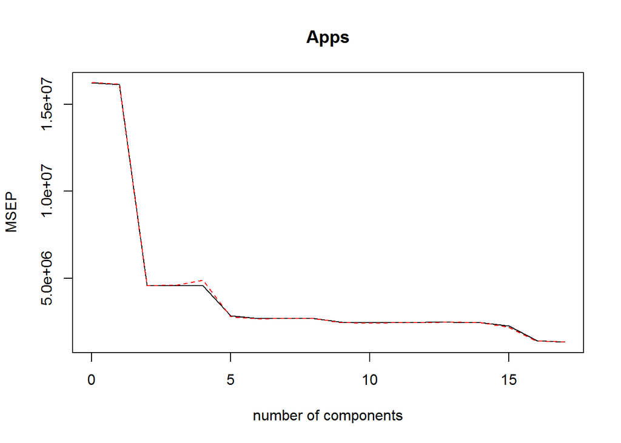

```r
validationplot(fit, val.type = "MSEP")
```

The lowest adjusted CV error rate is 1155 with M = 17 (i.e. no reduction of dimensionality provided better results than utilizing the full set of predictor variables – at least with this sample set of training data). We can now calculate the error rate on the test data which results in exactly the same error value as the linear regression model:

```r
{
pred = predict(fit, College[-index, ], ncomp = 17)
e = mean( (pred - College[-index, ]$Apps)^2)

results[nrow(results)+1,] = list('PRC', e)
results
}
```

|  | Model | MSPE |
| --- | --- | --- |
| 1 | Least Squares | 1075064 |
| 2 | Ridge Regression | 1192843 |
| 3 | The Lasso | 1077989 |
| 4 | PRC | 1075064 |

## f

Fit a PLS model on the training set, with M chosen by crossvalidation. Report the test error obtained, along with the value of M selected by cross-validation.

```r
{
set.seed(1)

fit = plsr(Apps ~ ., data = College[index, ], scale = T, validation = 'CV')
summary(fit)
}
```

```
## Data:    X dimension: 621 17
##  Y dimension: 621 1
## Fit method: kernelpls
## Number of components considered: 17
##
## VALIDATION: RMSEP
## Cross-validated using 10 random segments.
##        (Intercept)  1 comps  2 comps  3 comps  4 comps  5 comps  6 comps
## CV            4029     1942     1555     1496     1400     1235     1186
## adjCV         4029     1940     1546     1492     1382     1208     1176
##        7 comps  8 comps  9 comps  10 comps  11 comps  12 comps  13 comps
## CV        1172     1168     1168      1164      1164      1164      1163
## adjCV     1163     1160     1159      1156      1156      1156      1155
##        14 comps  15 comps  16 comps  17 comps
## CV         1163      1162      1162      1162
## adjCV      1155      1155      1155      1155
##
## TRAINING: % variance explained
##       1 comps  2 comps  3 comps  4 comps  5 comps  6 comps  7 comps
## X       26.22    35.30    62.44    64.74    66.69    71.46    75.92
## Apps    77.61    86.65    87.94    91.31    93.13    93.25    93.29
##       8 comps  9 comps  10 comps  11 comps  12 comps  13 comps  14 comps
## X       79.77    81.40     83.88     85.83     90.04     92.52     94.52
## Apps    93.34    93.39     93.41     93.43     93.43     93.44     93.44
##       15 comps  16 comps  17 comps
## X        97.07     98.41    100.00
## Apps     93.44     93.44     93.44
```

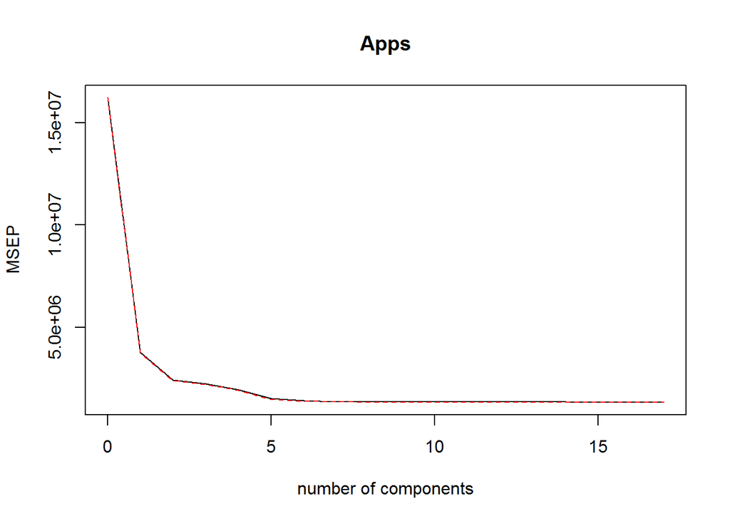

```r
validationplot(fit, val.type = "MSEP")
```

```r
{
pred = predict(fit, College[-index, ], ncomp = 10)
e = mean( (pred - College[-index, ]$Apps)^2)

results[nrow(results)+1,] = list('PLS', e)
results
}
```

|  | Model | MSPE |
| --- | --- | --- |
| 1 | Least Squares | 1075064 |
| 2 | Ridge Regression | 1192843 |
| 3 | The Lasso | 1077989 |
| 4 | PRC | 1075064 |
| 5 | PLS | 1075376 |

## g

Comment on the results obtained. How accurately can we predict the number of college applications received? Is there much difference among the test errors resulting from these five approaches?

The test error rates for each model we considered from smallest to largest in tabular and graphical format:

```r
{
results$MSPE = sapply(as.integer(results[, 2]), round)
results[order(results$MSPE),]
}
```

|  | Model | MSPE |
| --- | --- | --- |
| 1 | Least Squares | 1075063 |
| 4 | PRC | 1075063 |
| 5 | PLS | 1075375 |
| 3 | The Lasso | 1077989 |
| 2 | Ridge Regression | 1192843 |

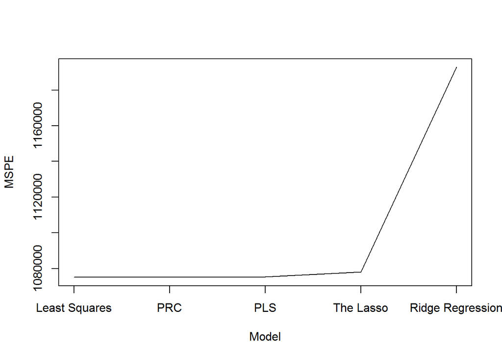

```r
{
  plot(results[order(results$MSPE),]$MSPE, type = 'l', ylab = "MSPE", xlab = "Model", xaxt="n")
  axis(1, at = 1:5, labels = results[order(results$MSPE),]$Model)
}
```

There is little difference in the models except for Ridge Regression which had the largest error rate, and the PRC which failed to reduce the number of predictors (and likely should be thrown out of the pool of possible models to be considered for this data set). Next, we can plot the actual application figures for the test data set against the predicted number of applications given by the linear model:

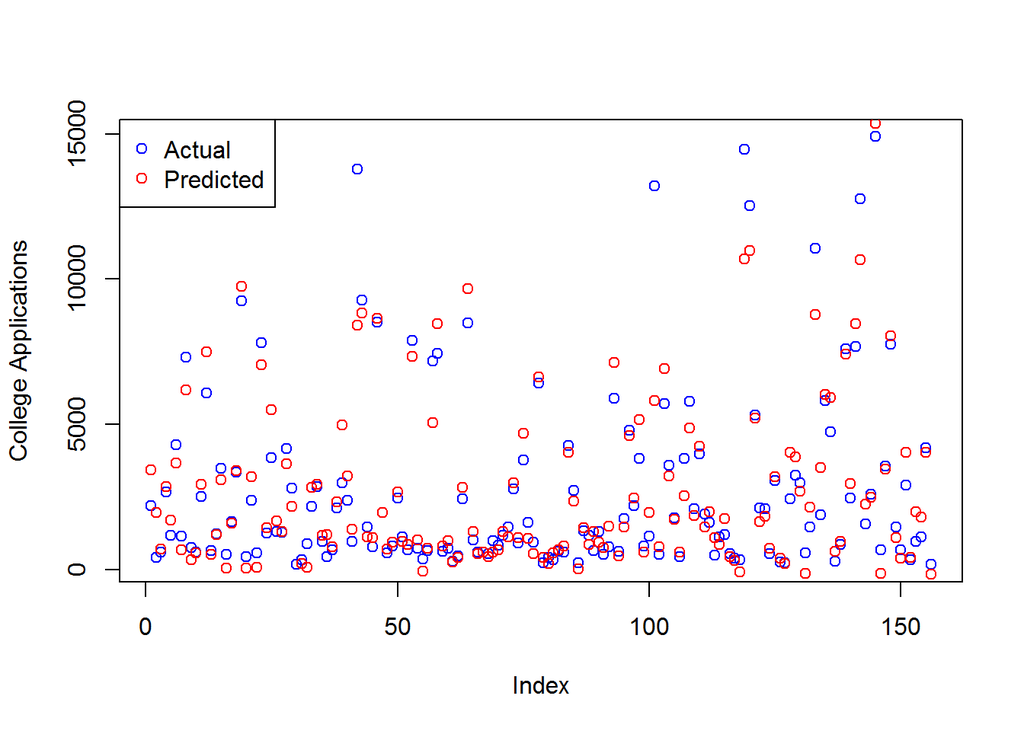

```r
{
  fit = lm(Apps ~ ., data = College[index, ])
  p = predict(fit, newdata = College[-index, ])


  plot(test$Apps, col = 'blue', ylab = 'College Applications')
  points(p, col = 'red')
  legend('topleft', legend=c("Actual", "Predicted"), col=c("blue", "red"), lty = c(0,0), pch=c(1,1))
}
```

For colleges where the number of applications was less than around 7,500 the model’s predictions fit the actual values closely. However, for colleges with applications > 7,500 the model became less accurate. We can examine the diagnostic plots of the least squares model to look for insights into this behavior:

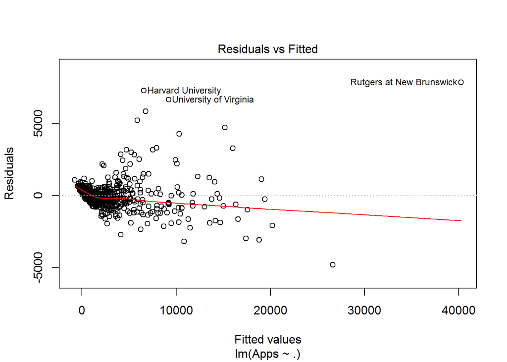

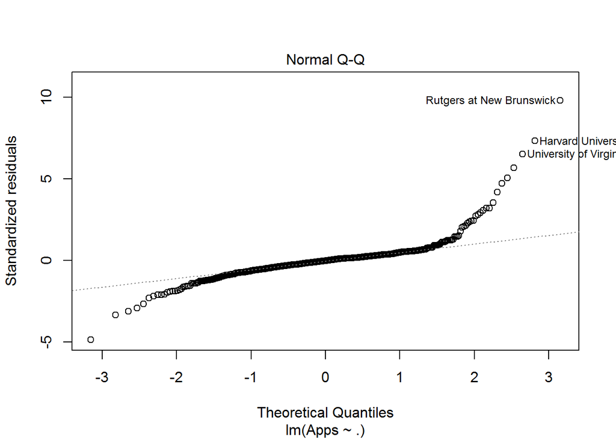

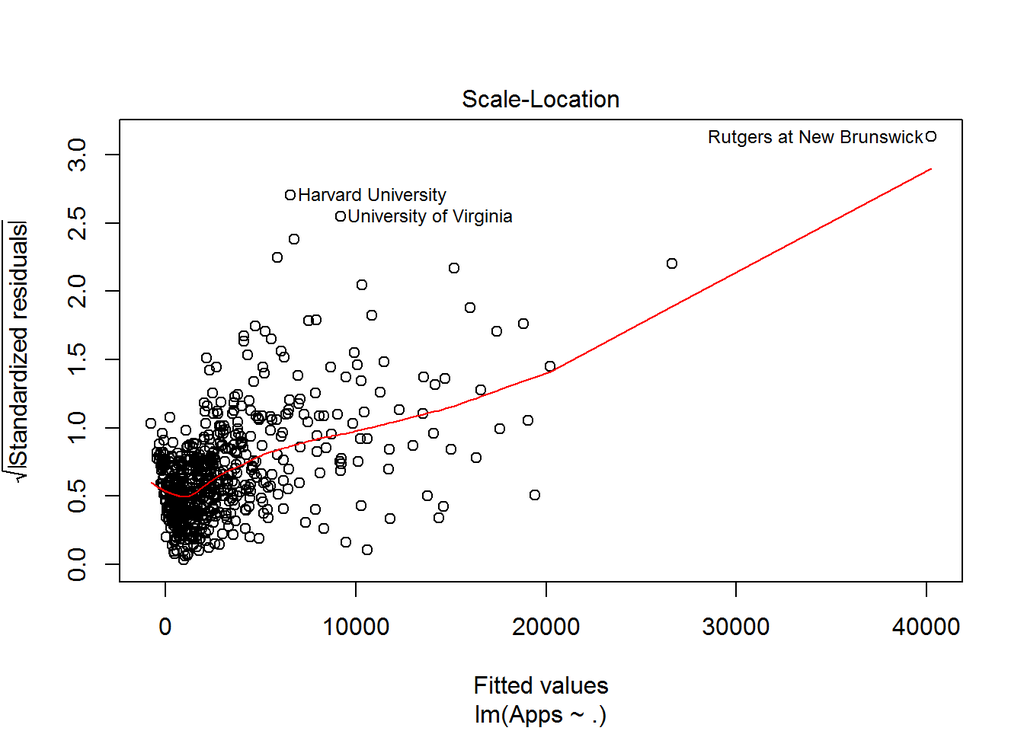

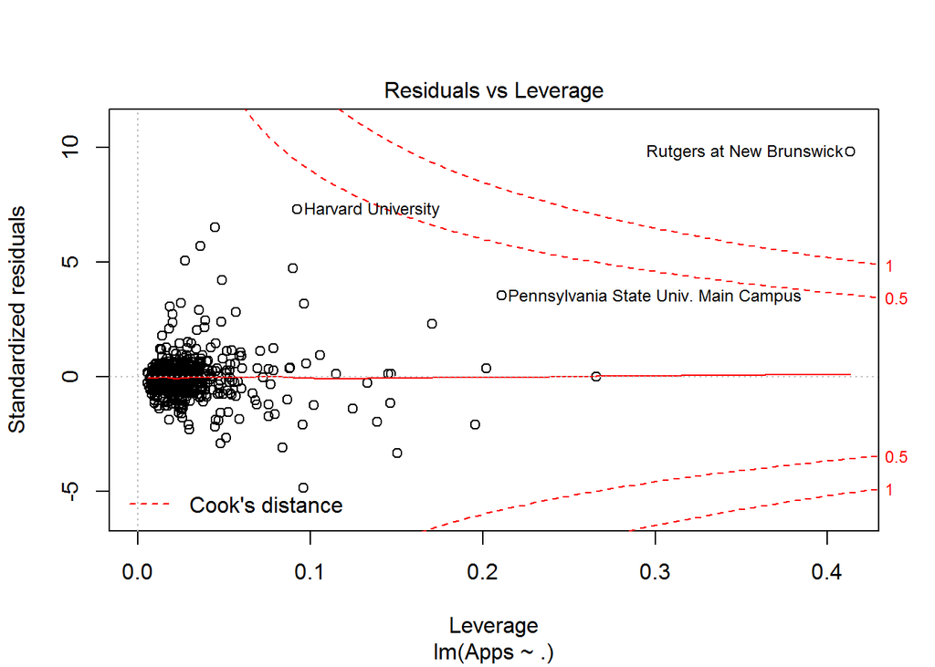

```r
plot(fit)
```

Observing the diagnostic plots for the least squares model we see three issues that would likely contribute to the model’s lack of fit for all College application values:

- The `Normal Q-Q` plot indicates the College data comes from a non-normal distribution. (The tails in the `Normal Q-Q` that curve off in the extremities usually mean that the data has more extreme values than would be expected if it truly came from a Normal distribution.)
- The `Scale-Location` graph indicates the data homoscedasticity issues
- The `Residuals vs Leverage` graph identifies at least one outlier with high leverage and several other values approaching outlier status

# 10

We have seen that as the number of features used in a model increases, the training error will necessarily decrease, but the test error may not. We will now explore this in a simulated data set.

## a

Generate a data set with p = 20 features, n = 1,000 observations, and an associated quantitative response vector generated according to the model `Y = xB + e`, where B has some elements that are exactly equal to zero.

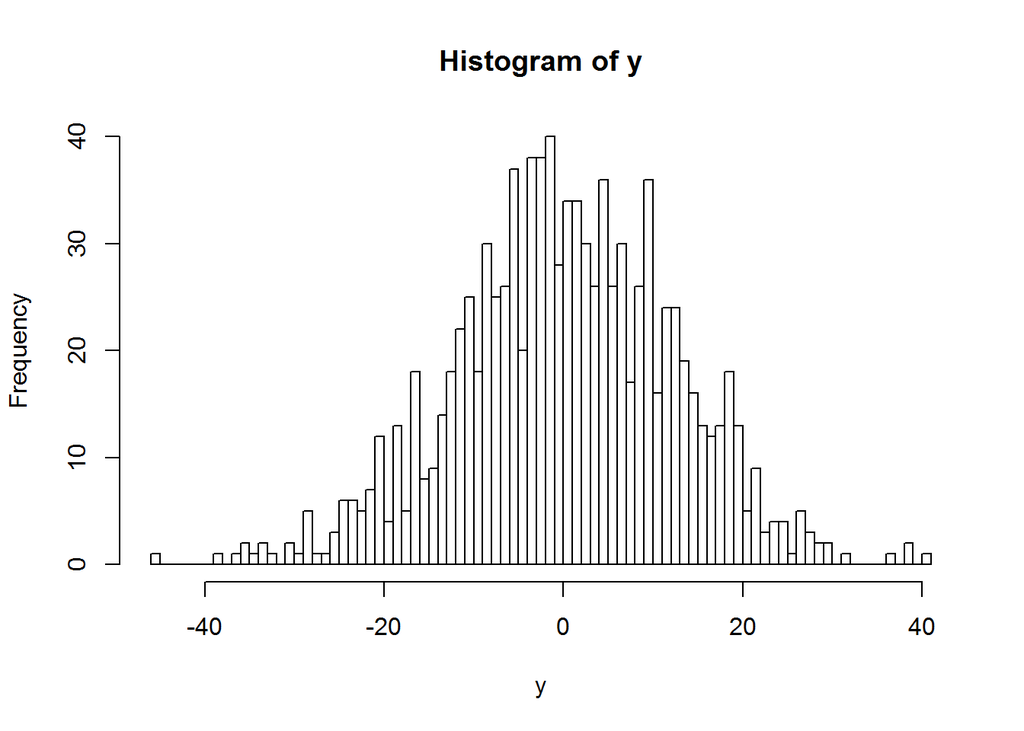

```r
{
set.seed(1)

e = rnorm(1000)
x = matrix(rnorm(1000*20), nrow = 1000, ncol=20)
b = sample(-5:5, 20, replace=TRUE)
b[c(3,6,7,10,13,17)] = 0

y = x %*% b + e
hist(y, breaks = 100)
}
```

## b

Split your data set into a training set containing 100 observations and a test set containing 900 observations.

```r
{
  set.seed(1)

  # 90/10 split of the data into train/test
  index = sample(seq_len(nrow(y)), size = floor(0.9 * nrow(y)))

  data = as.data.frame(cbind(y, x))
  colnames(data)[1] = 'y'
  colnames(data)[2:21] = paste('B', seq(1:(ncol(data)-1)), sep = '')

  train = data[index, ]
  test = data[-index, ]

  head(train)
}
```

|  | y | B1 | B2 | B3 | B4 | B5 | B6 | B7 | B8 | B9 | B10 | B11 | B12 | B13 | B14 | B15 | B16 | B17 | B18 | B19 | B20 |
| --- | --- | --- | --- | --- | --- | --- | --- | --- | --- | --- | --- | --- | --- | --- | --- | --- | --- | --- | --- | --- | --- |
| 266 | -0.9216397 | -0.005667893 | 1.3440537 | -0.7179062 | -0.6891166 | -1.1685642 | 1.0877666 | 0.71718980 | 0.7284158 | -0.7471278 | -0.5548599 | 0.9519526 | -0.7746717 | 1.2867301 | 0.4968921 | -0.7295269 | -0.15448917 | 1.3553067 | -0.9238298 | -0.2306135 | -0.02406128 |
| 372 | -3.8910764 | -0.282706438 | -0.8022214 | 0.9669120 | 0.6145544 | 1.4157153 | -0.7013637 | 0.87988876 | -0.4665364 | -1.8121029 | -0.0714856 | -0.1002573 | -0.3271840 | -0.9620332 | -1.1612594 | 0.6995660 | -1.87905888 | -0.3373504 | -0.3686822 | 1.6248576 | 1.12663788 |
| 572 | -3.6860844 | -2.153187751 | -0.3932218 | -0.4925393 | 0.6096216 | -1.7354382 | -0.8391105 | -0.38365216 | 0.3181191 | 0.5360374 | 1.1740390 | -0.8864760 | 1.3611243 | 0.6821296 | 0.4665313 | 1.3043178 | -0.29397560 | 0.2956409 | 1.1790168 | -0.4943536 | 1.23524484 |
| 906 | -6.1646743 | -2.630159317 | -1.9052435 | 1.0899624 | -0.9471659 | -0.3617737 | -0.3089424 | -0.54944345 | -0.6742103 | 1.4503185 | -0.3332856 | -0.1460637 | -0.7684532 | 0.1075969 | 0.8440311 | -2.9858672 | 0.61124217 | -0.0784486 | -0.7164010 | -0.2371630 | -0.53638454 |
| 201 | -18.9868771 | -1.557035744 | 0.9169380 | -0.1131544 | -1.4798343 | 0.4577942 | -1.2257122 | 0.07489798 | 0.2607109 | -0.7251209 | -0.2573674 | -1.1749409 | 1.1997508 | -0.2639580 | 0.1829194 | 0.1710224 | -0.58100814 | 0.3003228 | -0.9035973 | 1.1048717 | -1.12776402 |
| 894 | -8.3127035 | -0.885950264 | 1.1383174 | -0.7494808 | -0.3451478 | -0.6830112 | 0.5243968 | -1.52566125 | 1.6349865 | 1.2828937 | 1.3425186 | 0.5464349 | -0.4612921 | 1.2524234 | 0.9945885 | -1.0032869 | -0.02760356 | -0.2600455 | -0.1317923 | 1.1472634 | -0.49368079 |

## c

Perform best subset selection on the training set, and plot the training set MSE associated with the best model of each size.

- Mean squared error (MSE) measures the expected squared distance between an estimator and the true underlying parameter.
- The mean squared prediction error (MSPE) measures the expected squared distance between what your predictor predicts for a specific value and what the true value is.

```r
library(leaps)

fit = regsubsets(y ~ ., data = train, nvmax = 20)
# summary(fit)$outmat
```

```r
# Container for each best subset selection model's MSE error rate
errs = rep(20, 0)

# Convert the dataset to a matrix - This keeps the values of B and adds an intercept term equal to one
m = model.matrix(y ~ ., data = train)

# For each model
for (i in 1:20) {
  # Pull model's coefficents
  c = coef(fit, id = i)

  # Obtain values from the training data matrix lining up w/ the columns selected by the model
  v = m[, names(c)]

  # Predict the Y values
  p = v %*% c

  # Calculate the error of the Y value predictions vs. the actual training Y values
  errs[i] = mean( (train$y - p)^2 )
}

{
  print(which.min(errs))
  print(errs[which.min(errs)])
}
```

```
## [1] 20
## [1] 1.04544
```

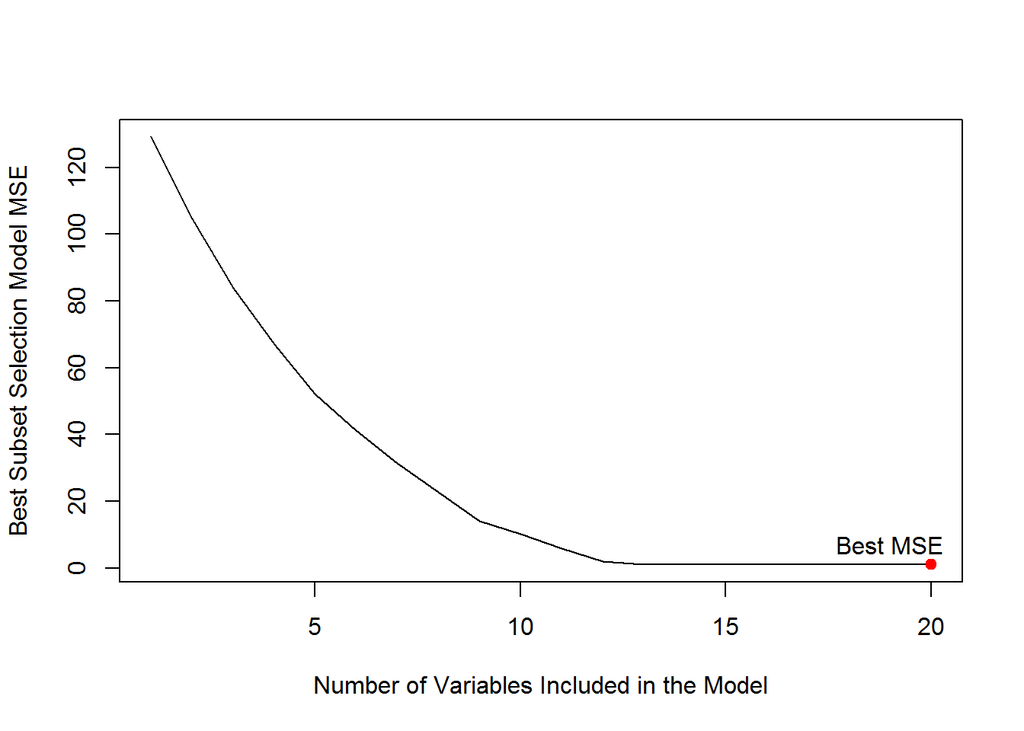

```r
{
  plot(errs, type = 'l', ylab = "Best Subset Selection Model MSE", xlab = "Number of Variables Included in the Model")
  points( which.min(errs), errs[which.min(errs)], pch = 19, col = 'red')
  text(which.min(errs)-1, errs[which.min(errs)]+6, labels = c("Best MSE"))
}
```

So, as per the main idea behind this exercise, we observe that as the number of features used in a model increases the training error will necessarily decrease.

## d

Plot the test set MSE associated with the best model of each size.

```r
# Container for each best subset selection model's MSE error rate
errs = rep(20, 0)

# Convert the dataset to a matrix - This keeps the values of B and adds an intercept term equal to one
m = model.matrix(y ~ ., data = test)

# For each model
for (i in 1:20) {
  # Pull model's coefficents
  c = coef(fit, id = i)

  # Obtain values from the test data matrix lining up w/ the columns selected by the model
  v = m[, names(c)]

  # Predict the Y values
  p = v %*% c

  # Calculate the error of the Y value predictions vs. the actual test Y values
  errs[i] = mean( (test$y - p)^2 )
}

{
  print(which.min(errs))
  print(errs[which.min(errs)])
}
```

```
## [1] 13
## [1] 1.108762
```

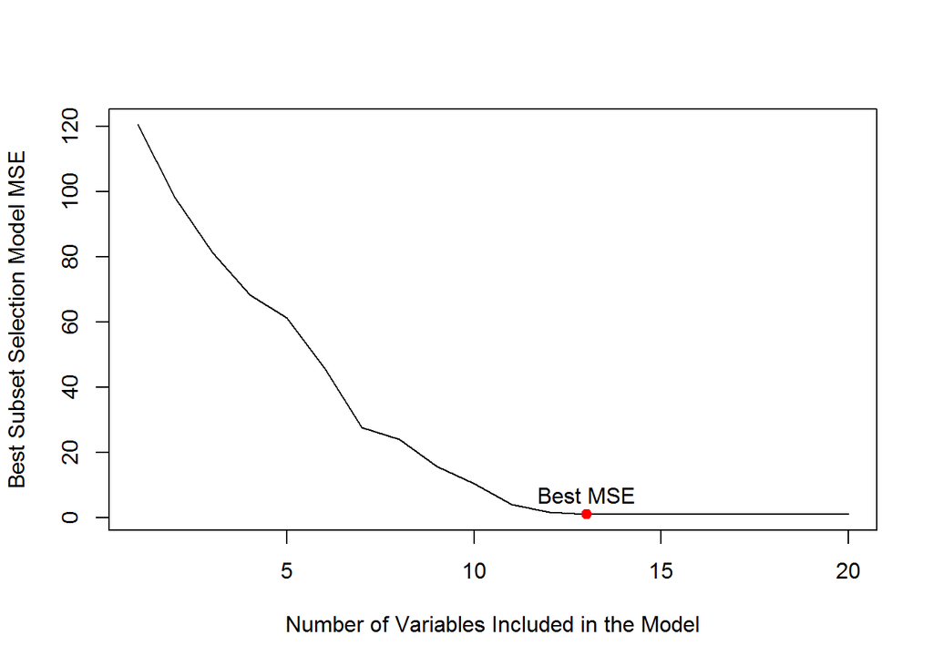

```r
{
  plot(errs, type = 'l', ylab = "Best Subset Selection Model MSE", xlab = "Number of Variables Included in the Model")
  points( which.min(errs), errs[which.min(errs)], pch = 19, col = 'red')
  text(which.min(errs), errs[which.min(errs)]+6, labels = c("Best MSE"))
}
```

## e

For which model size does the test set MSE take on its minimum value? Comment on your results.

The lowest MSE achieved on the test data set was when P = 13 with an MSPE rate of 1.108762.

## f

How does the model at which the test set MSE is minimized compare to the true model used to generate the data? Comment on the coefficient values.

Pull the coefficient values for P = 13, which did best on the test set data:

```r
tmp = as.data.frame(t(coef(fit, id = 13)))
```

Add the true model coefficient values to the dataframe and print:

```r
{
trueBetas = t(as.data.frame(c(1, b)))
colnames(trueBetas)[2:21] = paste('B', seq(1:(ncol(data)-1)), sep = '')
colnames(trueBetas)[1] = '(Intercept)'

rbind(tmp, trueBetas[, names(tmp)])
}
```

| (Intercept) | B1 | B2 | B4 | B5 | B8 | B9 | B11 | B12 | B14 | B15 | B16 | B19 | B20 |
| --- | --- | --- | --- | --- | --- | --- | --- | --- | --- | --- | --- | --- | --- |
| -0.01791484 | 2.009874 | 3.044827 | 4.958322 | 0.999586 | -2.965054 | 3.040328 | 3.965358 | 2.988974 | -3.972 | -4.019515 | -1.97638 | -4.957846 | 2.003027 |
| 1.00000000 | 2.000000 | 3.000000 | 5.000000 | 1.000000 | -3.000000 | 3.000000 | 4.000000 | 3.000000 | -4.000 | -4.000000 | -2.00000 | -5.000000 | 2.000000 |

The coefficient values for the test set MSE minimized model and the true model used to generate the data are almost identical. The best subset selection process was also able to eliminate those variables that were set to zero in the true model. (We know from above that the values `b[c(3,6,7,10,13,17)] = 0` in the true model.)

## g

Plot each model’s Beta values against the true model’s Beta values. How does this compare to the test MSE plot from (d)?

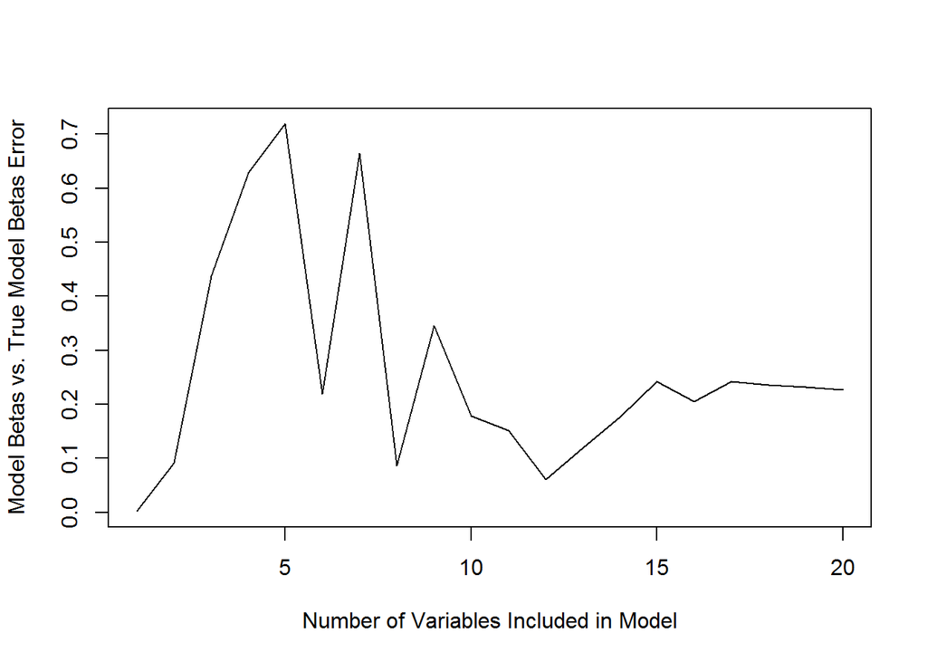

```r
# Container for each best subset selection model's Beta value difference from the true model's Beta values
errs = rep(20, 0)

# For each model
for (i in 1:20) {
  # Pull best subset selection model's coefficents (i.e. Beta values) less the intercept
  c = coef(fit, id = i)[-1]
  #print(c)

  # Obtain beta values from the true model lining up w/ the columns selected by the best subset selection model
  v = trueBetas[, names(c)]
  #print(v)

  # Calculate the error of the true model's beta values vs. the best subset selection model's beta values
  errs[i] = sqrt(sum(v - c)^2)
}

plot(errs, type = 'l', xlab = 'Number of Variables Included in Model', ylab = 'Model Betas vs. True Model Betas Error')
```

```r
which.min(errs[-1])
```

```
## [1] 11
```

```r
errs
```

```
##  [1] 0.001863947 0.091262459 0.437142660 0.628663238 0.718853887
##  [6] 0.219442853 0.664266516 0.086776874 0.344899524 0.178430231
## [11] 0.151973756 0.060916585 0.119499350 0.176923507 0.241799996
## [16] 0.204974802 0.241978082 0.235836210 0.231324386 0.226597923
```

This leads us to conclude that a minimal difference in model Beta values vs. true Beta values don’t necessarily correlate to a minimal or reduced model MSE error rate.

# 11

We will now try to predict per capital crime rate (crim) in the Boston data set.

```r
{
library(MASS)
attach(Boston)
dim(Boston)
}
```

```
## [1] 506  14
```

```r
head(Boston)
```

|  | crim | zn | indus | chas | nox | rm | age | dis | rad | tax | ptratio | black | lstat | medv |
| --- | --- | --- | --- | --- | --- | --- | --- | --- | --- | --- | --- | --- | --- | --- |
| 1 | 0.00632 | 18 | 2.31 | 0 | 0.538 | 6.575 | 65.2 | 4.0900 | 1 | 296 | 15.3 | 396.90 | 4.98 | 24.0 |
| 2 | 0.02731 | 0 | 7.07 | 0 | 0.469 | 6.421 | 78.9 | 4.9671 | 2 | 242 | 17.8 | 396.90 | 9.14 | 21.6 |
| 3 | 0.02729 | 0 | 7.07 | 0 | 0.469 | 7.185 | 61.1 | 4.9671 | 2 | 242 | 17.8 | 392.83 | 4.03 | 34.7 |
| 4 | 0.03237 | 0 | 2.18 | 0 | 0.458 | 6.998 | 45.8 | 6.0622 | 3 | 222 | 18.7 | 394.63 | 2.94 | 33.4 |
| 5 | 0.06905 | 0 | 2.18 | 0 | 0.458 | 7.147 | 54.2 | 6.0622 | 3 | 222 | 18.7 | 396.90 | 5.33 | 36.2 |
| 6 | 0.02985 | 0 | 2.18 | 0 | 0.458 | 6.430 | 58.7 | 6.0622 | 3 | 222 | 18.7 | 394.12 | 5.21 | 28.7 |

```r
summary(Boston)
```

```
##       crim                zn             indus            chas
##  Min.   : 0.00632   Min.   :  0.00   Min.   : 0.46   Min.   :0.00000
##  1st Qu.: 0.08204   1st Qu.:  0.00   1st Qu.: 5.19   1st Qu.:0.00000
##  Median : 0.25651   Median :  0.00   Median : 9.69   Median :0.00000
##  Mean   : 3.61352   Mean   : 11.36   Mean   :11.14   Mean   :0.06917
##  3rd Qu.: 3.67708   3rd Qu.: 12.50   3rd Qu.:18.10   3rd Qu.:0.00000
##  Max.   :88.97620   Max.   :100.00   Max.   :27.74   Max.   :1.00000
##       nox               rm             age              dis
##  Min.   :0.3850   Min.   :3.561   Min.   :  2.90   Min.   : 1.130
##  1st Qu.:0.4490   1st Qu.:5.886   1st Qu.: 45.02   1st Qu.: 2.100
##  Median :0.5380   Median :6.208   Median : 77.50   Median : 3.207
##  Mean   :0.5547   Mean   :6.285   Mean   : 68.57   Mean   : 3.795
##  3rd Qu.:0.6240   3rd Qu.:6.623   3rd Qu.: 94.08   3rd Qu.: 5.188
##  Max.   :0.8710   Max.   :8.780   Max.   :100.00   Max.   :12.127
##       rad              tax           ptratio          black
##  Min.   : 1.000   Min.   :187.0   Min.   :12.60   Min.   :  0.32
##  1st Qu.: 4.000   1st Qu.:279.0   1st Qu.:17.40   1st Qu.:375.38
##  Median : 5.000   Median :330.0   Median :19.05   Median :391.44
##  Mean   : 9.549   Mean   :408.2   Mean   :18.46   Mean   :356.67
##  3rd Qu.:24.000   3rd Qu.:666.0   3rd Qu.:20.20   3rd Qu.:396.23
##  Max.   :24.000   Max.   :711.0   Max.   :22.00   Max.   :396.90
##      lstat            medv
##  Min.   : 1.73   Min.   : 5.00
##  1st Qu.: 6.95   1st Qu.:17.02
##  Median :11.36   Median :21.20
##  Mean   :12.65   Mean   :22.53
##  3rd Qu.:16.95   3rd Qu.:25.00
##  Max.   :37.97   Max.   :50.00
```

```r
#?Boston
```

**Create train and test sets**

```r
{
  # 80/20 split of the data into train/test
  index = sample(seq_len(nrow(Boston)), size = floor(0.8 * nrow(Boston)))

  train = Boston[index, ]
  test = Boston[-index, ]

  train.matrix = model.matrix(crim ~ ., data = train)[,-1]
  test.matrix = model.matrix(crim ~ ., data = test)[,-1]

  # Scaling reference:
  # https://stats.stackexchange.com/questions/89172/how-to-scale-new-observations-for-making-predictions-when-the-model-was-fitted-w

  train.scaled = scale(train)
  test.scaled = scale(test, attr(train.scaled, "scaled:center"), attr(train.scaled, "scaled:scale"))

  train.matrix.scaled = model.matrix(crim ~ ., data = as.data.frame(train.scaled))[,-1]
  test.matrix.scaled = model.matrix(crim ~ ., data = as.data.frame(test.scaled))[,-1]
}
```

## a

Try out some of the regression methods explored in this chapter, such as best subset selection, the lasso, ridge regression, and PCR. Present and discuss results for the approaches that you consider.

### Baseline - Least Squares

As a baseline to compare the models against we’ll first train a least squares model with 10-fold cross-validation on the Boston data set and compute the test set MSPE:

```r
library(caret)
library(tidyverse)
```

```r
mspe = data.frame(Model = character(),
                MSPE = double(),
                stringsAsFactors=FALSE)

set.seed(1)
model <- caret::train(
  crim ~ .,
  train.scaled,
  method = "lm",
  trControl = trainControl(
    method = "cv",
    number = 10,
    verboseIter = FALSE
  )
)

summary(model)
```

```
##
## Call:
## lm(formula = .outcome ~ ., data = dat)
##
## Residuals:
##     Min      1Q  Median      3Q     Max
## -1.5392 -0.1960 -0.0396  0.1187  7.7413
##
## Coefficients:
##               Estimate Std. Error t value Pr(>|t|)
## (Intercept) -2.996e-16  3.420e-02   0.000  1.00000
## zn           1.009e-01  5.270e-02   1.914  0.05639 .
## indus       -3.905e-02  7.043e-02  -0.554  0.57961
## chas        -2.003e-02  3.574e-02  -0.561  0.57544
## nox         -1.238e-01  7.254e-02  -1.706  0.08875 .
## rm          -7.362e-02  5.414e-02  -1.360  0.17470
## age          3.212e-03  6.070e-02   0.053  0.95782
## dis         -1.882e-01  7.101e-02  -2.650  0.00837 **
## rad          6.128e-01  9.010e-02   6.802 3.90e-11 ***
## tax         -6.594e-02  1.044e-01  -0.632  0.52801
## ptratio     -5.633e-02  4.855e-02  -1.160  0.24673
## black       -1.886e-01  4.045e-02  -4.662 4.31e-06 ***
## lstat        1.116e-01  6.460e-02   1.728  0.08480 .
## medv        -7.531e-02  6.725e-02  -1.120  0.26346
## ---
## Signif. codes:  0 '***' 0.001 '**' 0.01 '*' 0.05 '.' 0.1 ' ' 1
##
## Residual standard error: 0.6873 on 390 degrees of freedom
## Multiple R-squared:  0.5428, Adjusted R-squared:  0.5276
## F-statistic: 35.62 on 13 and 390 DF,  p-value: < 2.2e-16
```

```r
e = mean((as.data.frame(test.scaled)$crim - predict(model, test.scaled)) ^ 2)
mspe = rbind(mspe, data.frame('Model' = "LS", 'MSPE' = e))
```

### Best Subset Selection

**Helper Functions**

```r
get_model_formula <- function(id, object, outcome){
  # Get the selected model as given by the 'id' argument value
  models <- summary(object)$which[id,-1]

  # Get a list of which predictors were selected by the model
  predictors <- names(which(models == TRUE))

  # Build model formula
  predictors <- paste(predictors, collapse = "+")
  as.formula(paste0(outcome, "~", predictors))
}

get_cv_error <- function(model.formula, train.data){
  set.seed(1)

  # Perform CV
  train.control <- trainControl(method = "cv", number = 10)
  cv <- train(model.formula, data = train.data, method = "lm", trControl = train.control)

  # Return results
  cv$results$RMSE
}
```

**Train the models**

```r
# Create the collection of best subset collection models
fit = regsubsets(crim ~ ., data = as.data.frame(train.scaled), nvmax = ncol(train.scaled)-1)

# Perform k-fold Cross-validation on each model to determine which has the lowest error on the training data
indices = 1:(ncol(train.scaled)-1)
errs = map(indices, get_model_formula, fit, 'crim') %>%
  map(get_cv_error, as.data.frame(train.scaled)) %>%
  unlist()

coef(fit, which.min(errs))
```

```
##   (Intercept)            zn           nox           dis           rad
## -1.344411e-17  8.852242e-02 -1.181829e-01 -1.319311e-01  5.301024e-01
##         black         lstat
## -1.918846e-01  1.932246e-01
```

**Calculate test set MSPE**

```r
set.seed(1)
model <- caret::train(
  get_model_formula(which.min(errs), fit, 'crim'),
  test.scaled,
  method = "lm"
)

summary(model)
```

```
##
## Call:
## lm(formula = .outcome ~ ., data = dat)
##
## Residuals:
##     Min      1Q  Median      3Q     Max
## -1.8652 -0.4629 -0.1794  0.2220  9.8994
##
## Coefficients:
##             Estimate Std. Error t value Pr(>|t|)
## (Intercept)  0.06142    0.14376   0.427   0.6702
## zn           0.29087    0.20275   1.435   0.1547
## nox         -0.06521    0.27898  -0.234   0.8157
## dis         -0.32847    0.24771  -1.326   0.1880
## rad          0.67390    0.16125   4.179  6.5e-05 ***
## black        0.19482    0.19494   0.999   0.3201
## lstat        0.45706    0.17978   2.542   0.0126 *
## ---
## Signif. codes:  0 '***' 0.001 '**' 0.01 '*' 0.05 '.' 0.1 ' ' 1
##
## Residual standard error: 1.4 on 95 degrees of freedom
## Multiple R-squared:  0.3497, Adjusted R-squared:  0.3086
## F-statistic: 8.513 on 6 and 95 DF,  p-value: 2.107e-07
```

```r
e = mean((as.data.frame(test.scaled)$crim - predict(model, test.scaled)) ^ 2)
mspe = rbind(mspe, data.frame('Model' = "BSS", 'MSPE' = e))
```

### Ridge Regression

```r
# Setup 10-fold cross-validation
fitControl <- trainControl(method = "cv", number = 10)
set.seed(1)
model <- caret::train(
  crim ~ .,
  data = train.scaled,
  method = "foba",
  trControl = fitControl
)

model
```

```
## Ridge Regression with Variable Selection
##
## 404 samples
##  13 predictor
##
## No pre-processing
## Resampling: Cross-Validated (10 fold)
## Summary of sample sizes: 363, 363, 364, 363, 364, 364, ...
## Resampling results across tuning parameters:
##
##   lambda  k   RMSE       Rsquared   MAE
##   1e-05    2  0.6648029  0.6001222  0.3149001
##   1e-05    7  0.6285252  0.6505049  0.3262149
##   1e-05   13  0.6260907  0.6542936  0.3302770
##   1e-03    2  0.6647244  0.6000647  0.3147533
##   1e-03    7  0.6283527  0.6505858  0.3259208
##   1e-03   13  0.6259011  0.6543766  0.3297921
##   1e-01    2  0.6572645  0.5984990  0.3025104
##   1e-01    7  0.6238803  0.6479045  0.3107287
##   1e-01   13  0.6238803  0.6479045  0.3107287
##
## RMSE was used to select the optimal model using the smallest value.
## The final values used for the model were k = 7 and lambda = 0.1.
```

```r
e = mean((as.data.frame(test.scaled)$crim - predict(model, test.scaled)) ^ 2)
mspe = rbind(mspe, data.frame('Model' = "RR", 'MSPE' = e))
```

## The Lasso

We will utilize the caret library to train and select the best lamba value for the Lasso model using the training data. However, since the caret library doesn’t have a generic “Lasso” implementation we’ll utilize the Relaxed Lasso instead. Additionally the Lasso is a feature selection model, so one or more of the predictor coefficients may be set to zero.

```r
# Setup 10-fold cross-validation
fitControl <- trainControl(method = "cv", number = 10)

set.seed(1)
model <- caret::train(
  crim ~ .,
  data = train.scaled,
  method = "relaxo",
  trControl = fitControl
)

model
```

```
## Relaxed Lasso
##
## 404 samples
##  13 predictor
##
## No pre-processing
## Resampling: Cross-Validated (10 fold)
## Summary of sample sizes: 363, 363, 364, 363, 364, 364, ...
## Resampling results across tuning parameters:
##
##   phi  lambda       RMSE       Rsquared   MAE
##   0.1    0.3381738  0.6237768  0.6541170  0.3284121
##   0.1    6.6324991  0.6294983  0.6468662  0.3216002
##   0.1  130.0811878  0.6423310  0.6255291  0.3058837
##   0.5    0.3381738  0.6233631  0.6544109  0.3266934
##   0.5    6.6324991  0.6249376  0.6503558  0.3134360
##   0.5  130.0811878  0.6446733  0.6255291  0.3066246
##   0.9    0.3381738  0.6230195  0.6546321  0.3251010
##   0.9    6.6324991  0.6219720  0.6523815  0.3079359
##   0.9  130.0811878  0.6831233  0.6255291  0.3511175
##
## RMSE was used to select the optimal model using the smallest value.
## The final values used for the model were lambda = 6.632499 and phi = 0.9.
```

```r
e = mean((as.data.frame(test.scaled)$crim - predict(model, test.scaled)) ^ 2)
mspe = rbind(mspe, data.frame('Model' = "LAS", 'MSPE' = e))
```

## Principal Component Analysis

```r
# Setup 10-fold cross-validation
fitControl <- trainControl(method = "cv", number = 10)

# Custom tuning grid
grid <-  expand.grid(ncomp = (1:7))

set.seed(1)
model <- caret::train(
  crim ~ .,
  data = train.scaled,
  method = "pcr",
  trControl = fitControl,
  tuneGrid = grid
)

model
```

```
## Principal Component Analysis
##
## 404 samples
##  13 predictor
##
## No pre-processing
## Resampling: Cross-Validated (10 fold)
## Summary of sample sizes: 363, 363, 364, 363, 364, 364, ...
## Resampling results across tuning parameters:
##
##   ncomp  RMSE       Rsquared   MAE
##   1      0.7236527  0.4779083  0.4376966
##   2      0.7241194  0.4768781  0.4449580
##   3      0.6517114  0.6120242  0.3464981
##   4      0.6492225  0.6155607  0.3470991
##   5      0.6503362  0.6146652  0.3494187
##   6      0.6567412  0.6057162  0.3492534
##   7      0.6579417  0.6039332  0.3510233
##
## RMSE was used to select the optimal model using the smallest value.
## The final value used for the model was ncomp = 4.
```

```r
e = mean((as.data.frame(test.scaled)$crim - predict(model, test.scaled)) ^ 2)
mspe = rbind(mspe, data.frame('Model' = "PCA", 'MSPE' = e))
```

## Partial Least Squares

```r
# Setup 10-fold cross-validation
fitControl <- trainControl(method = "cv", number = 10)

# Custom tuning grid
grid <-  expand.grid(ncomp = (1:7))

set.seed(1)
model <- caret::train(
  crim ~ .,
  data = train.scaled,
  method = "kernelpls",
  trControl = fitControl,
  tuneGrid = grid
)

model
```

```
## Partial Least Squares
##
## 404 samples
##  13 predictor
##
## No pre-processing
## Resampling: Cross-Validated (10 fold)
## Summary of sample sizes: 363, 363, 364, 363, 364, 364, ...
## Resampling results across tuning parameters:
##
##   ncomp  RMSE       Rsquared   MAE
##   1      0.6949993  0.5318639  0.4153106
##   2      0.6402334  0.6314915  0.3367274
##   3      0.6374460  0.6386737  0.3319910
##   4      0.6310840  0.6449614  0.3337261
##   5      0.6273519  0.6504154  0.3301716
##   6      0.6251735  0.6554862  0.3317978
##   7      0.6300521  0.6498487  0.3335317
##
## RMSE was used to select the optimal model using the smallest value.
## The final value used for the model was ncomp = 6.
```

```r
e = mean((as.data.frame(test.scaled)$crim - predict(model, test.scaled)) ^ 2)
mspe = rbind(mspe, data.frame('Model' = "PLS", 'MSPE' = e))
```

## Summary

```r
mspe[order(mspe$MSPE),]
```

|  | Model | MSPE |
| --- | --- | --- |
| 2 | BSS | 1.824213 |
| 6 | PLS | 1.997265 |
| 1 | LS | 1.997543 |
| 4 | LAS | 2.047554 |
| 3 | RR | 2.073861 |
| 5 | PCA | 2.097171 |

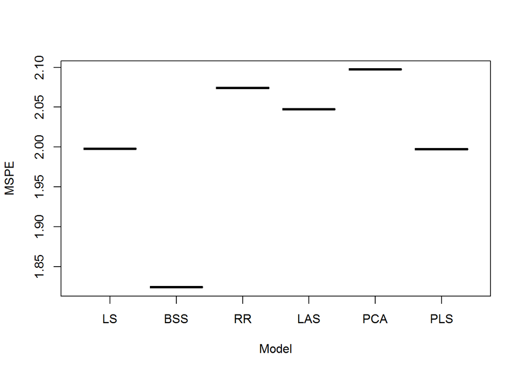

```r
plot(mspe[order(mspe$MSPE),])
```